# Business analytics: churn prediction in Telco

Kostrova Anna

10/24/2020

# Introduction

```r
library(readr)
library(dplyr)
library(ggplot2)
library(gridExtra)
library(grid)
library(psych)
library(gtable)
library(knitr)
library(kableExtra)
library(formattable)
library(caret)
library(MASS)
library(pROC)
library(GGally)
library(ggcorrplot)
library(purrr)
library(cluster)
library(summarytools)
library(qwraps2)
library(DT)
library(gtable)
```

```r
WA <- read_csv("~/Documents/БИЗНЕСАНАЛ/WA_Fn-UseC_-Telco-Customer-Churn.csv")
```

In this project, I want to predict Telco customer churn based on their behavior. This dataset taken from Kaggle dataset. Firstly, I will do a short exploratory analysis with plots to get acquainted with the data at hand. Then, I will make a cluster analysis and define groups, where the persent of cluents who have churned higher. Thirdly, I will use logistic regression to predict churn. Along the way, the most important factors for predicting churn will be outlined. Finally, I will give some reccomendation to the company about the fact how it can decrease customer churn.

# Data overview

Let’s download data and have a briefly look on metrics:

```r
dfs = dfSummary(WA[,-1],
                style = "grid",
                valid.col = FALSE, varnumbers = FALSE, tmp.img.dir = "/tmp")

dfs$Missing <- NULL
dfs$`Freqs (% of Valid)` <- NULL

print(dfs,
      headings = FALSE,
      footnote = NA,
      max.tbl.height = 500,
      max.tbl.width = 250,
      method = "render")
```

| **Variable** | **Stats / Values** | **Graph** |
| --- | --- | --- |
| gender [character] | 1. Female 2. Male |  |
| SeniorCitizen [numeric] | Min : 0 Mean : 0.2 Max : 1 |  |
| Partner [character] | 1. No 2. Yes |  |
| Dependents [character] | 1. No 2. Yes |  |
| tenure [numeric] | Mean (sd) : 32.4 (24.6) min ≤ med ≤ max: 0 ≤ 29 ≤ 72 IQR (CV) : 46 (0.8) |  |
| PhoneService [character] | 1. No 2. Yes |  |
| MultipleLines [character] | 1. No 2. No phone service 3. Yes |  |
| InternetService [character] | 1. DSL 2. Fiber optic 3. No |  |
| OnlineSecurity [character] | 1. No 2. No internet service 3. Yes |  |
| OnlineBackup [character] | 1. No 2. No internet service 3. Yes |  |
| DeviceProtection [character] | 1. No 2. No internet service 3. Yes |  |
| TechSupport [character] | 1. No 2. No internet service 3. Yes |  |
| StreamingTV [character] | 1. No 2. No internet service 3. Yes |  |
| StreamingMovies [character] | 1. No 2. No internet service 3. Yes |  |
| Contract [character] | 1. Month-to-month 2. One year 3. Two year |  |
| PaperlessBilling [character] | 1. No 2. Yes |  |
| PaymentMethod [character] | 1. Bank transfer (automatic) 2. Credit card (automatic) 3. Electronic check 4. Mailed check |  |
| MonthlyCharges [numeric] | Mean (sd) : 64.8 (30.1) min ≤ med ≤ max: 18.2 ≤ 70.3 ≤ 118.8 IQR (CV) : 54.3 (0.5) |  |
| TotalCharges [numeric] | Mean (sd) : 2283.3 (2266.8) min ≤ med ≤ max: 18.8 ≤ 1397.5 ≤ 8684.8 IQR (CV) : 3393.3 (1) |  |
| Churn [character] | 1. No 2. Yes |  |

All in all there are 7043 observations and 21 variables.

The data set includes information about:

- The column “Churn” is customers who left within the last month.
- Services that each customer has signed up for phone, multiple lines, internet, online security, online backup, device protection, tech support, and streaming TV and movies.
- Customer account information: how long they have been a customer, contract, payment method, paperless billing, monthly charges, and total charges.
- Demographic info about customers: gender, age range, and if they have partners and dependents

Let’s Check for any missing data in the data set.

```r
kable(paste0(round(((nrow(WA) - nrow(na.omit(WA)))/nrow(WA))*100,2), "%"), col.names = "Percent of NA") %>%
  kable_styling(bootstrap_options=c("bordered", "responsive","striped"), full_width = FALSE)
```

| Percent of NA |
| --- |
| 0.16% |

```r
WA = WA %>% na.omit()
```

Only 0.16% missing values. I delete them.

## How big is the problem?

In order to evaluate how big the problem of customer churn from the company is, it is necessary to know the percentage of these customers from the total number.

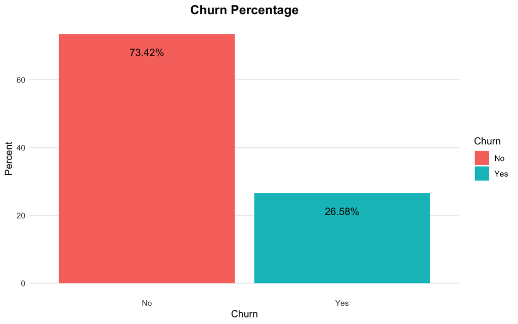

```r
th = theme(plot.title = element_text(size=14, hjust = 0.5, face="bold"),
        axis.ticks = element_blank(),
        panel.grid = element_blank(),
        rect = element_blank(),
        panel.grid.major.y = element_line(color = "grey92", size = 0.5))

WA %>%
  group_by(Churn) %>%
  summarise(Number = n()) %>%
  mutate(Percent = prop.table(Number)*100) %>%
ggplot(aes(Churn, Percent)) +
  geom_col(aes(fill = Churn)) +
  labs(title = "Churn Percentage") +
  theme(plot.title = element_text(hjust = 0.5)) +
  geom_text(aes(label = sprintf("%.2f%%", Percent)), vjust = 3,size = 4) +
  th
```

From the plot, we can see that the percentage of customer that churn is around 27%. It is a litle bit more than 1/4 from the all cluents. It still not a very big problem, but I think, it is also not a great result. To understand, why this problem can occure, let’s make some correlations.

## Explore correlations of churn

### Continuos variables

To begin with, we will look at the dependence of customer churn on numerical variables, such as Tenure, Monthly Charges and Total Charges. Small description for is above:

- **tenure**: Number of months the customer has stayed with the company
- **MonthlyCharges**: The amount charged to the customer monthly
- **TotalCharges**: The total amount charged to the customer

*In fact, there is another numerical variable in the data, but it is so defined by R, although it is a factor variable in the raw data from Kaggle. It is Senior Citizen.*

Let’s have a briefly look on this metrics.

```r
WA_contin = WA %>% dplyr::select(tenure, MonthlyCharges, TotalCharges)

kable(describe(WA_contin)) %>%
  kable_styling(bootstrap_options=c("bordered", "responsive","striped")) %>% scroll_box(width = "700px", height = "150px")
```

|  | vars | n | mean | sd | median | trimmed | mad | min | max | range | skew | kurtosis | se |
| --- | --- | --- | --- | --- | --- | --- | --- | --- | --- | --- | --- | --- | --- |
| tenure | 1 | 7032 | 32.42179 | 24.54526 | 29.000 | 31.48685 | 32.61720 | 1.00 | 72.00 | 71.0 | 0.2376294 | -1.3881476 | 0.2927037 |
| MonthlyCharges | 2 | 7032 | 64.79821 | 30.08597 | 70.350 | 65.01030 | 35.65653 | 18.25 | 118.75 | 100.5 | -0.2220082 | -1.2566125 | 0.3587770 |
| TotalCharges | 3 | 7032 | 2283.30044 | 2266.77136 | 1397.475 | 1970.14024 | 1812.92328 | 18.80 | 8684.80 | 8666.0 | 0.9612323 | -0.2332742 | 27.0313843 |

From the statistics above, we can see that the longest tenure is 72 months or 6 years, and the maximum monthly charge is 118.75 dollars. For Total Charges the maximum is 8684.80 dollars. The minimum tenure is 1 month and minimum monthly charge is about 18.25 dollars. For Total Charges minimum is 18.80 dollars. The customer can expect to have a monthly charge of about 64.80 dollars and the mean tenure is 32 months or around 3 years. The customer can expect to have a Total Charge is 2283.30 dollars.

The use of the metric is not indicative or effective. If the user leaves, the total costs are clearly lower. It is difficult to say anything about correlation with customer churn. Also, we may not consider this variable because it correlates with the other two variables that we are exploring.

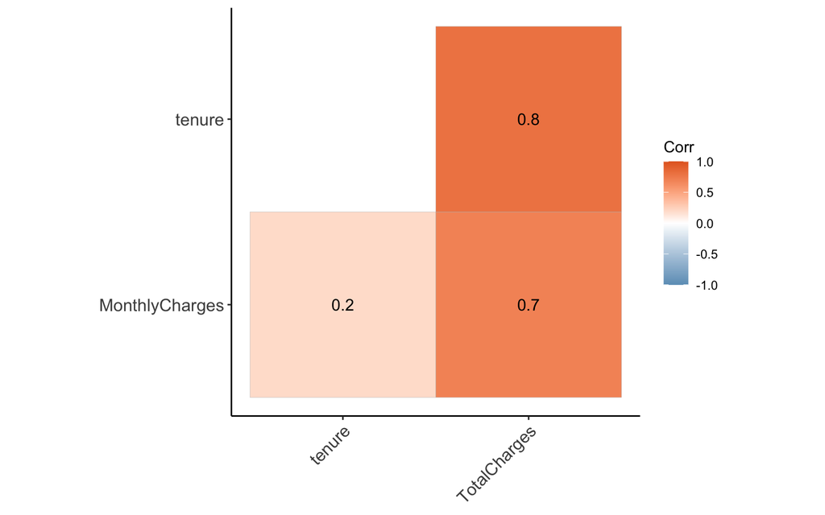

```r
corr <- round(cor(WA_contin), 1)
ggcorrplot(corr, hc.order = TRUE, type = "lower",
   lab = TRUE,
   ggtheme = ggplot2::theme_classic,
   colors = c("#6D9EC1", "white", "#E46726"))
```

Now, I would like to make plots, which can illustrates graphically data.

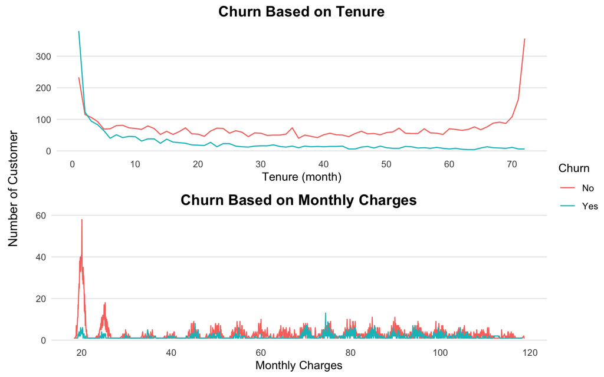

```r
graph1 = WA %>%
  group_by(tenure, Churn) %>%
  summarise(Number = n()) %>%
  ggplot(aes(tenure, Number)) +
  geom_line(aes(col = Churn)) +
  labs(x = "Tenure (month)",
       y = "",
       title = "Churn Based on Tenure") +
  scale_x_continuous(breaks = seq(0, 80, 10)) +
  th

graph2 = WA %>%
  group_by(MonthlyCharges, Churn) %>%
  summarise(Number = n()) %>%
  ggplot(aes(MonthlyCharges, Number)) +
  geom_line(aes(col = Churn)) +
  labs(x = "Monthly Charges",
       y = "",
       title = "Churn Based on Monthly Charges") +
  scale_x_continuous(breaks = seq(0, 120, 20)) +
  th

legend = gtable_filter(ggplotGrob(graph2), "guide-box")

#plot graphs
grid.arrange(arrangeGrob(graph1+ theme(legend.position="none"), graph2 + theme(legend.position="none"), nrow = 2,
             left = textGrob("Number of Customer", rot = 90, vjust = 1,
                                          gp = gpar(fontsize = 12))),
             legend,
    widths=unit.c(unit(1, "npc") - legend$width, legend$width),
    nrow=1)
```

From the graph we can see that the highest churn happen mostly after 1 month usage. It is noticeable that customers leave much less frequently after 25 months. The monthly charges chart shows that most of the loyal customers that stayed with the company had a lower monthly charge than most of the customers that churned.

### Demographic data

I was interested in studying how customer churn can be related to the demographic characteristics of customers. These characteristics include the following variables:

- **gender**: gender (female, male)
- **Senior Citizen**: Whether the customer is a senior citizen or not (1, 0)
- **Partner** Whether: the customer has a partner or not (Yes, No)
- **Dependents**: Whether the customer has dependents or not (Yes, No)

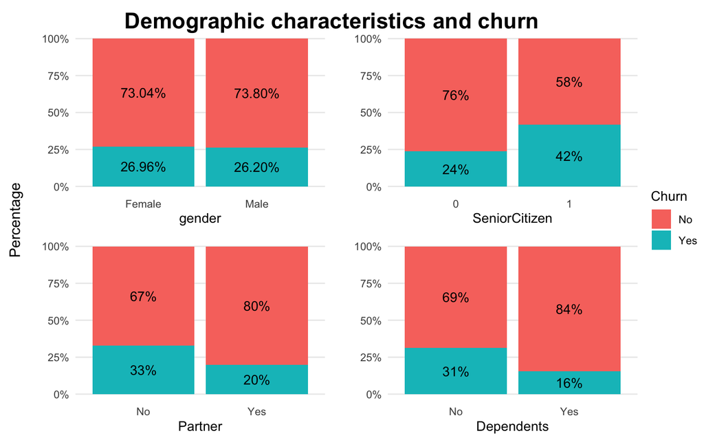

```r
# AS I said earlier, SeniorCitizen is numeric, but it is a factor)
WA <- WA %>%
  mutate(SeniorCitizen = as.factor(SeniorCitizen))

p1 = WA %>% ggplot(aes(x=gender,fill=Churn)) +
  geom_bar(position = 'fill') +
  labs(y = "") +
  geom_text(data = . %>%
              group_by(gender, Churn) %>%
              tally() %>%
              mutate(p = n / sum(n)) %>%
              ungroup(),
            aes(y = p, label = scales::percent(p)),
            position = position_stack(vjust = 0.5),
            show.legend = FALSE) +
  scale_y_continuous(labels = scales::percent)+
  th +
  theme(legend.position = "none")

p2 = WA %>% ggplot(aes(x=SeniorCitizen,fill=Churn)) +
  geom_bar(position = 'fill') +
  labs(y = "") +
  geom_text(data = . %>%
              group_by(SeniorCitizen, Churn) %>%
              tally() %>%
              mutate(p = n / sum(n)) %>%
              ungroup(),
            aes(y = p, label = scales::percent(p)),
            position = position_stack(vjust = 0.5),
            show.legend = FALSE) +
  scale_y_continuous(labels = scales::percent) +
  th +
  theme(legend.position = "none")

p3 = WA %>% ggplot(aes(x=Partner,fill=Churn)) +
  geom_bar(position = 'fill') +
  labs(y = "") +
  geom_text(data = . %>%
              group_by(Partner, Churn) %>%
              tally() %>%
              mutate(p = n / sum(n)) %>%
              ungroup(),
            aes(y = p, label = scales::percent(p)),
            position = position_stack(vjust = 0.5),
            show.legend = FALSE) +
  scale_y_continuous(labels = scales::percent)+
  th +
  theme(legend.position = "none")

p4 = WA %>% ggplot(aes(x=Dependents,fill=Churn)) +
  geom_bar(position = 'fill') +
  labs(y = "") +
  geom_text(data = . %>%
              group_by(Dependents, Churn) %>%
              tally() %>%
              mutate(p = n / sum(n)) %>%
              ungroup(),
            aes(y = p, label = scales::percent(p)),
            position = position_stack(vjust = 0.5),
            show.legend = FALSE) +
  scale_y_continuous(labels = scales::percent)+
  th +
  theme(legend.position = "none")

g = WA %>% ggplot(aes(x=Dependents,fill=Churn)) +
  geom_bar(position = 'fill') +
  labs(y = "Percentage")+
  theme_classic()

legend = gtable_filter(ggplotGrob(g), "guide-box")

grid.arrange(arrangeGrob(p1, p2, p3, p4, nrow = 2,
             top = textGrob("Demographic characteristics and churn", vjust = 1, gp = gpar(fontface = "bold", cex = 1.5)),
             left = textGrob("Percentage", rot = 90, vjust = 1,
                                          gp = gpar(fontsize = 12))),
             legend,
    widths=unit.c(unit(1, "npc") - legend$width, legend$width),
    nrow=1)
```

From the customer characteristics, I can get several information :

- From the gender, male and female seems to have same proportion to churn.
- Senior citizens are more likely to churn
- Customer without partner are more likely to churn compared to customer who have partner
- Customer without dependents are more likely to churn compared to customer with dependents

### Services of the company and churn

Also, Telecom companie have different services which can be used by cluents. The list of this services are below:

- **PhoneService**: Whether the customer has a phone service or not (Yes, No)
- **MultipleLines**: Whether the customer has multiple lines or not (Yes, No, No phone service)
- **InternetService**: Customer’s internet service provider (DSL, Fiber optic, No)
- **OnlineSecurity**: Whether the customer has online security or not (Yes, No, No internet service)
- **OnlineBackup**: Whether the customer has online backup or not (Yes, No, No internet service)
- **DeviceProtection**: Whether the customer has device protection or not (Yes, No, No internet service)
- **TechSupport**: Whether the customer has tech support or not (Yes, No, No internet service)
- **StreamingTV**: Whether the customer has streaming TV or not (Yes, No, No internet service)
- **StreamingMovies**: Whether the customer has streaming movies or not (Yes, No, No internet service)

And there are plots which illustarates the distribution of churned and not churned cluents in each category.

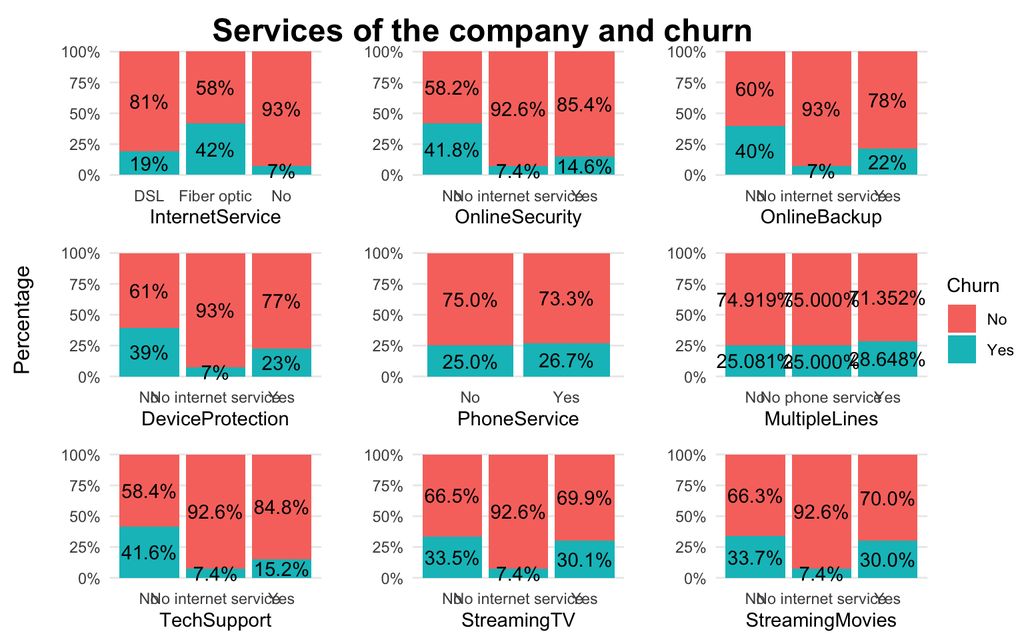

```r
p5 = WA %>% ggplot(aes(x=InternetService,fill=Churn)) +
  geom_bar(position = 'fill') +
  labs(y = "") +
  geom_text(data = . %>%
              group_by(InternetService, Churn) %>%
              tally() %>%
              mutate(p = n / sum(n)) %>%
              ungroup(),
            aes(y = p, label = scales::percent(p)),
            position = position_stack(vjust = 0.5),
            show.legend = FALSE) +
  scale_y_continuous(labels = scales::percent)+
  th +
  theme(legend.position = "none")

p6 = WA %>% ggplot(aes(x=OnlineSecurity,fill=Churn)) +
  geom_bar(position = 'fill') +
  labs(y = "") +
  geom_text(data = . %>%
              group_by(OnlineSecurity, Churn) %>%
              tally() %>%
              mutate(p = n / sum(n)) %>%
              ungroup(),
            aes(y = p, label = scales::percent(p)),
            position = position_stack(vjust = 0.5),
            show.legend = FALSE) +
  scale_y_continuous(labels = scales::percent)+
  th +
  theme(legend.position = "none")

p7 = WA %>% ggplot(aes(x=OnlineBackup,fill=Churn)) +
  geom_bar(position = 'fill') +
  labs(y = "") +
  geom_text(data = . %>%
              group_by(OnlineBackup, Churn) %>%
              tally() %>%
              mutate(p = n / sum(n)) %>%
              ungroup(),
            aes(y = p, label = scales::percent(p)),
            position = position_stack(vjust = 0.5),
            show.legend = FALSE) +
  scale_y_continuous(labels = scales::percent)+
  th +
  theme(legend.position = "none")

p8 = WA %>% ggplot(aes(x=DeviceProtection,fill=Churn)) +
  geom_bar(position = 'fill') +
  labs(y = "") +
  geom_text(data = . %>%
              group_by(DeviceProtection, Churn) %>%
              tally() %>%
              mutate(p = n / sum(n)) %>%
              ungroup(),
            aes(y = p, label = scales::percent(p)),
            position = position_stack(vjust = 0.5),
            show.legend = FALSE) +
  scale_y_continuous(labels = scales::percent)+
  th +
  theme(legend.position = "none")

p9 = WA %>% ggplot(aes(x=PhoneService,fill=Churn)) +
  geom_bar(position = 'fill') +
  labs(y = "") +
  geom_text(data = . %>%
              group_by(PhoneService, Churn) %>%
              tally() %>%
              mutate(p = n / sum(n)) %>%
              ungroup(),
            aes(y = p, label = scales::percent(p)),
            position = position_stack(vjust = 0.5),
            show.legend = FALSE) +
  scale_y_continuous(labels = scales::percent)+
  th +
  theme(legend.position = "none")

p10 = WA %>% ggplot(aes(x=MultipleLines,fill=Churn)) +
  geom_bar(position = 'fill') +
  labs(y = "") +
  geom_text(data = . %>%
              group_by(MultipleLines, Churn) %>%
              tally() %>%
              mutate(p = n / sum(n)) %>%
              ungroup(),
            aes(y = p, label = scales::percent(p)),
            position = position_stack(vjust = 0.5),
            show.legend = FALSE) +
  scale_y_continuous(labels = scales::percent)+
  th +
  theme(legend.position = "none")

p11 = WA %>% ggplot(aes(x=TechSupport,fill=Churn)) +
  geom_bar(position = 'fill') +
  labs(y = "") +
  geom_text(data = . %>%
              group_by(TechSupport, Churn) %>%
              tally() %>%
              mutate(p = n / sum(n)) %>%
              ungroup(),
            aes(y = p, label = scales::percent(p)),
            position = position_stack(vjust = 0.5),
            show.legend = FALSE) +
  scale_y_continuous(labels = scales::percent)+
  th +
  theme(legend.position = "none")

p12 = WA %>% ggplot(aes(x=StreamingTV,fill=Churn)) +
  geom_bar(position = 'fill') +
  labs(y = "") +
  geom_text(data = . %>%
              group_by(StreamingTV, Churn) %>%
              tally() %>%
              mutate(p = n / sum(n)) %>%
              ungroup(),
            aes(y = p, label = scales::percent(p)),
            position = position_stack(vjust = 0.5),
            show.legend = FALSE) +
  scale_y_continuous(labels = scales::percent)+
  th +
  theme(legend.position = "none")

p13 = WA %>% ggplot(aes(x=StreamingMovies,fill=Churn)) +
  geom_bar(position = 'fill') +
  labs(y = "") +
  geom_text(data = . %>%
              group_by(StreamingMovies, Churn) %>%
              tally() %>%
              mutate(p = n / sum(n)) %>%
              ungroup(),
            aes(y = p, label = scales::percent(p)),
            position = position_stack(vjust = 0.5),
            show.legend = FALSE) +
  scale_y_continuous(labels = scales::percent)+
  th +
  theme(legend.position = "none")

grid.arrange(arrangeGrob(p5, p6, p7, p8, p9, p10, p11, p12,p13, nrow = 3,
             top = textGrob("Services of the company and churn", vjust = 1, gp = gpar(fontface = "bold", cex = 1.5)),
             left = textGrob("Percentage", rot = 90, vjust = 1,
                                          gp = gpar(fontsize = 12))),
             legend,
    widths=unit.c(unit(1, "npc") - legend$width, legend$width),
    nrow=1)
```

From the service that used by the customer, I can get several information :

- Customer who use fibser optic in internet service are more likely to churn compared to others
- Customer who don’t use online security, online backup, device protection, streaming TV, and tech support are more likely to churn compared to others
- The presence or non-existence of a telephone service at the customer’s premises does not affect the customer’s churn from the company in any way.

## Contract and payment status

The remaining categorical variables are related to contract and payment status. There are the foloowing variables:

- **Contract**: The contract term of the customer (Month-to-month, One year, Two year)
- **PaperlessBilling**: Whether the customer has paperless billing or not (Yes, No)
- **PaymentMethod**: The customer’s payment method (Electronic check, Mailed check, Bank transfer (automatic), Credit card (automatic))

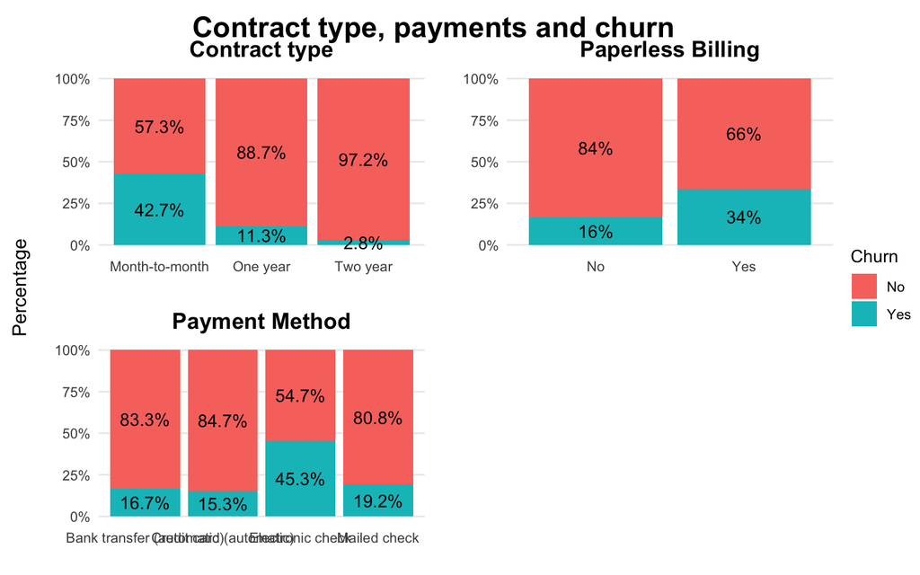

```r
p14 = WA %>% ggplot(aes(x=PaymentMethod,fill=Churn)) +
  geom_bar(position = 'fill') +
  labs(y = "", x ="", title = "Payment Method") +
  geom_text(data = . %>%
              group_by(PaymentMethod, Churn) %>%
              tally() %>%
              mutate(p = n / sum(n)) %>%
              ungroup(),
            aes(y = p, label = scales::percent(p)),
            position = position_stack(vjust = 0.5),
            show.legend = FALSE) +
  scale_y_continuous(labels = scales::percent)+
  th +
  theme(legend.position = "none")

p15 = WA %>% ggplot(aes(x=Contract,fill=Churn)) +
  geom_bar(position = 'fill') +
  labs(y = "", x ="", title = "Contract type") +
  geom_text(data = . %>%
              group_by(Contract, Churn) %>%
              tally() %>%
              mutate(p = n / sum(n)) %>%
              ungroup(),
            aes(y = p, label = scales::percent(p)),
            position = position_stack(vjust = 0.5),
            show.legend = FALSE) +
  scale_y_continuous(labels = scales::percent)+
  th +
  theme(legend.position = "none")

p16 = WA %>% ggplot(aes(x=PaperlessBilling,fill=Churn)) +
  geom_bar(position = 'fill') +
  labs(y = "", x="", title = "Paperless Billing") +
  geom_text(data = . %>%
              group_by(PaperlessBilling, Churn) %>%
              tally() %>%
              mutate(p = n / sum(n)) %>%
              ungroup(),
            aes(y = p, label = scales::percent(p)),
            position = position_stack(vjust = 0.5),
            show.legend = FALSE) +
  scale_y_continuous(labels = scales::percent)+
  th +
  theme(legend.position = "none")

grid.arrange(arrangeGrob(p15, p16, p14, nrow = 2,
             top = textGrob("Contract type, payments and churn", vjust = 1, gp = gpar(fontface = "bold", cex = 1.5)),
             left = textGrob("Percentage", rot = 90, vjust = 1,
                                          gp = gpar(fontsize = 12))),
             legend,
    widths=unit.c(unit(1, "npc") - legend$width, legend$width),
    nrow=1)
```

# Cluster analysis

## Recoding and Standardize continuous variables

```r
WA_new = WA %>% dplyr::select(-customerID, -TotalCharges)

WA_new$PhoneService = if_else(WA_new$PhoneService == "Yes", 1, 0)

WA_new$MultipleLines = if_else(WA_new$MultipleLines == "Yes", 1, if_else(WA_new$MultipleLines == "No", 0, 0))
WA_new$InternetService = if_else(WA_new$InternetService == "DSL", 1, if_else(WA_new$InternetService == "No", 0, 2))
WA_new$OnlineSecurity = if_else(WA_new$OnlineSecurity == "Yes", 1, if_else(WA_new$OnlineSecurity == "No", 0, 0))
WA_new$OnlineBackup = if_else(WA_new$OnlineBackup == "Yes", 1, if_else(WA_new$OnlineBackup == "No", 0, 0))
WA_new$DeviceProtection = if_else(WA_new$DeviceProtection == "Yes", 1, if_else(WA_new$DeviceProtection == "No", 0, 0))
WA_new$TechSupport = if_else(WA_new$TechSupport == "Yes", 1, if_else(WA_new$TechSupport == "No", 0, 0))
WA_new$StreamingTV = if_else(WA_new$StreamingTV == "Yes", 1, if_else(WA_new$StreamingTV == "No", 0, 0))
WA_new$StreamingMovies = if_else(WA_new$StreamingMovies == "Yes", 1, if_else(WA_new$StreamingMovies == "No", 0, 0))

WA_new$all_services = WA_new$MultipleLines + WA_new$InternetService + WA_new$OnlineSecurity + WA_new$OnlineBackup + WA_new$DeviceProtection + WA_new$TechSupport + WA_new$StreamingTV + WA_new$StreamingMovies

# Create the mean-sd standardization function
mean_sd_standard <- function(x) {
    (x-mean(x))/sd(x)}

# Apply the function to each numeric variable in the clustering set
WA_new <- WA_new %>%
    mutate(MonthlyCharges_stand = mean_sd_standard(MonthlyCharges))

WA_new <- WA_new %>%
    mutate(tenure_stand = mean_sd_standard(tenure))

WA_new <- WA_new %>%
    mutate(all_services_stnd = mean_sd_standard(all_services))
```

# Elbow (Scree) Plot & Silhouette analysis

Since the data is quite large and I know nothing about the TV company’s clients, it is difficult to assume how many clusters there will be and what number will be optimal. Therefore, I decided to use two methods to determine the optimal number of clusters.

```r
WA_cluster = WA_new %>% dplyr::select(MonthlyCharges_stand, tenure_stand, all_services_stnd)

# Use map_dbl to run many models with varying value of k (centers)
tot_withinss <- map_dbl(1:10,  function(k){
  model <- kmeans(x = WA_cluster, centers = k)
  model$tot.withinss
})

# Generate a data frame containing both k and tot_withinss
elbow_df <- data.frame(
  k = 1:10,
  tot_withinss = tot_withinss
)

# Plot the elbow plot
elbow_plot = ggplot(elbow_df, aes(x = k, y = tot_withinss)) +
  geom_line() +
  labs(x = "Number of clusters", y ="Total within-cluster sum of squares",title = "Elbow plot") +
  scale_x_continuous(breaks = 1:10) + theme_linedraw() +
  theme(plot.title = element_text(size=14, hjust = 0.5, face="bold"))
```

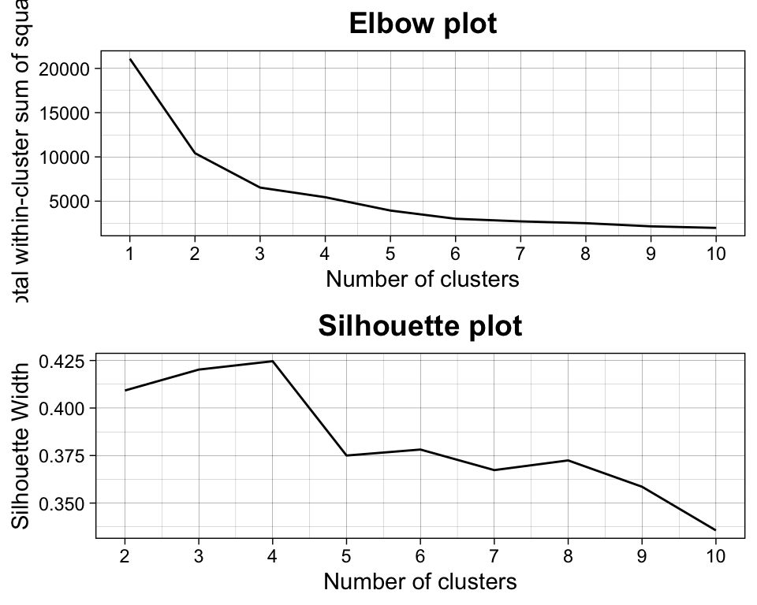

```r
# # Use map_dbl to run many models with varying value of k
# sil_width <- map_dbl(2:10,  function(k){
#   model <- pam(x = WA_cluster, k = k)
#   model$silinfo$avg.width
# })
#
# # Generate a data frame containing both k and sil_width
# sil_df <- data.frame(
#   k = 2:10,
#   sil_width = sil_width
# )

# write.csv(sil_df, "~/Documents/БИЗНЕСАНАЛ/sil_df.csv")
sil_df <- read_csv("~/Documents/БИЗНЕСАНАЛ/sil_df.csv")
sil_df = sil_df[,-1]

# Plot the relationship between k and sil_width
sil_plot = ggplot(sil_df, aes(x = k, y = sil_width)) +
  geom_line()  +
  labs(x = "Number of clusters", y ="Silhouette Width", title = "Silhouette plot") +
  scale_x_continuous(breaks = 2:10) + theme_linedraw() +
  theme(plot.title = element_text(size=14, hjust = 0.5, face="bold"))

grid.arrange(elbow_plot,sil_plot, nrow =2)
```

As we can see, the elbow method reccomend to devide all data in 2 clusters or 3 clusters, but for our deep analys it looks like really strange (exactly, when I go to the Interpretation part, I understand, why elbow shows the best variant is 2 clusters). Silhouete plot shows that if I take 4 clusters then most of observations are similar to the cluster it is assigned relative to other clusters. After that analysis I decided to devide all data to 4 clusters and save it in dataset.

I use set.seed equal to 123, because I want to save my results. Also, I added to my dataset new colomn *“Cluster”*, were save the number of cluster. The table below shows the distribution by clusters.

```r
set.seed(123)
clusters <- kmeans(WA_new[,21:23], 4)

# Save the cluster number in the dataset as column 'Borough'
WA_new$Cluster <- as.factor(clusters$cluster)

# Look at the distribution of cluster
kable(table(WA_new$Cluster))%>%
  kable_styling(bootstrap_options=c("bordered", "responsive","striped"), full_width = FALSE)
```

| Var1 | Freq |
| --- | --- |
| 1 | 1750 |
| 2 | 1490 |
| 3 | 1727 |
| 4 | 2065 |

## Interpretation of the clusters

To start assessing the quality and distinctiveness of these groups, we will look at the average values of the groups for each cluster by original variables in our clustering dataset. This will give us the first clear idea of how groups behave. Below I visualize the clusters with a Parallel Coordinate Plot. Also I make a barplot with percent of churn in all clusters.

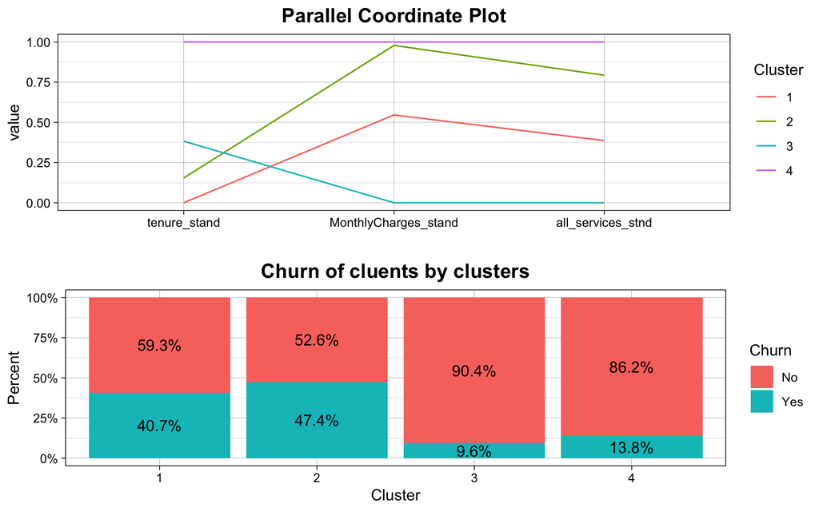

```r
# Group by the cluster assignment and calculate averages
WA_clus_avg <- WA_new %>%
    dplyr::select(MonthlyCharges_stand, tenure_stand, all_services_stnd,Cluster) %>%
    group_by(Cluster) %>%
    summarize_if(is.numeric,mean)

# Create the min-max scaling function
min_max_standard <- function(x) {
  (x - min(x))/(max(x)-min(x))
}

# Apply this function to each numeric variable in the bustabit_clus_avg object
WA_avg_minmax <- WA_clus_avg %>%
    mutate_if(is.numeric, min_max_standard)

# Load the GGally package

# Create a parallel coordinate plot of the values, starts with column 2
parrallel_plot = ggparcoord(WA_avg_minmax, columns = 2:ncol(WA_avg_minmax),
           groupColumn = "Cluster", scale = "globalminmax", order = "skewness")  +
  labs(x = "", title = "Parallel Coordinate Plot") + theme_linedraw() +
  theme(plot.title = element_text(size=14, hjust = 0.5, face="bold"))

clusters_churn_plot = WA_new %>% ggplot(aes(x=Cluster,fill=Churn)) +
  geom_bar(position = 'fill') +
  labs(y = "Percent", title = "Churn of cluents by clusters") +
  geom_text(data = . %>%
              group_by(Cluster, Churn) %>%
              tally() %>%
              mutate(p = n / sum(n)) %>%
              ungroup(),
            aes(y = p, label = scales::percent(p)),
            position = position_stack(vjust = 0.5),
            show.legend = FALSE) +
  scale_y_continuous(labels = scales::percent)+ theme_linedraw() +
  theme(plot.title = element_text(size=14, hjust = 0.5, face="bold"))

grid.arrange(parrallel_plot, clusters_churn_plot, nrow = 2)
```

**Interpretation**: 4th cluster have the highest values compared to the rest of the clusters for all the permanent ones. The clusters are distributed as follows by *tensure*: clients from the 4th class stayed the longest, clients from the 3rd claster also stayed the longest, but approximately 2 times less frequently, while clients from the 2nd and 1st clusters stayed the shortest. In general, this distribution corresponds to the outflow of clients from these clusters: in cluster 1 and 2 the outflow accounts for almost half of all data, it could be assumed that people from these clusters could also leave the company in the near future. In clusters 3 and 4, outflow accounts for less than 15% of the total data in each cluster. In terms of monthly payments, again, it turns out that people from the 4 clusters pay the most, which is not surprising, because if you look at whether they use services, you can see that they have the maximum, and for services you need an extra payment. At the same time, people in the 3 clusters pay the lowest monthly fee, but they also hardly use any different services. Customers from the second cluster also pay quite a lot for monthly services, but they use fewer services than customers from the 4th cluster. In general, 1 pays less than 2 and 4, but again, they use fewer services. In general, we can understand why the outflow of clients is more frequent in clusters 1 and 2 - they pay a price every month that is disproportionate to the services they use. However, it is possible that the services they use, or the type of service provider they use, somehow affect the monthly costs.